# Clasificador de tweets

En este notebook se muestran los pasos seguidos para la realización de la segunda práctica de la asignatura, incluyendo el ejercicio opcional con el análisis del sentimiento de los tweets personalidades elegidas.

# Importación de librerías

Antes de comenzar con la selección de las personalidades y la extracción de tweets, mostramos a continuación las librerías que se van a usar a lo largo de la práctica.

```python
# librería que nos permite extraer los tweets
import twitter
import numpy as np
import pandas as pd

# para realizar extracciones basadas en expresiones regulares
import re

# función de scikit-learn necesarias para vectorizar la colección de tweets
from sklearn.feature_extraction.text import TfidfVectorizer
# modelo para el entrenamiento
from sklearn import svm
# funciones necesarias para el análisis de los resultados de test obtenidos
from sklearn.metrics import confusion_matrix, accuracy_score, ConfusionMatrixDisplay

# librería de manejo de emojis
import emoji

# para hacer gráficas e histogramas en el análisis de sentimientos y las matrices de confusión
%matplotlib inline
import matplotlib.pyplot as plt

# función que permite seleccionar un elemento de una tupla para realizar operaciones sobre él
from operator import itemgetter
```

# Extracción de tweets

Para poder extraer datos de twitter es necesario poseer una cuenta *developer*, y a partir de ella crear una **Twitter App**, que es simplemente una aplicación cliente para desarrolladores que permite acceder al contenido de Twitter para que puedan realizar diferentes análisis. En nuestro caso se ha creado la app usando el perfil `RfJorda`.

Para realizar la extracción de tweets, se ha decidido usar la librería `python-twitter`. Tras realizar ciertas comparaciones con la librería `tweepy`, se concluyó que las dos son muy similares y tienen las mismas funcionalidades para extraer información de Twitter. Una diferencia entre ambas es que `tweepy` usa una clase denominada `Cursor` que te permite manejar la paginación directamente, siendo cada página el número de tweets que se puede obtener en una misma extracción. Aunque esta característica es interesante, cuando se probó su ejecución fue un poco más larga que la de `python-twitter`, y como ya se había empezado con esta última, se continuó usándola.

Una vez creamos la Twitter App, se nos asignan una serie de claves que nos permiten acceder a la API de Twitter. Esas claves se las tenemos que pasar al constructor `twitter.Api`. Además de las claves, hemos pasado dos parámetros más al constructor:

- Sleep_on_rate_limit: dado que en cada extracción solo se puede obtener un número limitado de tweets, y entre cada una de ellas hay que esperar un tiempo determinado para poder volver a extraer tweets, hemos de "dormir" el programa hasta que se puedan extraer de nuevo. En lugar de manejar esto manualmente cuando se lean los tweets (con time.sleep), establecer este parámetro a True nos permite decirle a la API que queremos que el programa se quede dormido hasta que se pueda volver a extraer tweets.
- Tweet_mode: toma dos posibles valores: `compatibility` y `extended`. El valor por defecto es `compatibility`, y hace que los tweets devueltos por la API estén truncados a 140 caracteres. Por otro lado, el valor `extended` permite obtener los tweets completos. Esta es una nueva característica que se añadió en Septiembre de 2016, ya que previamente solo se extraían tweets truncados. El valor elegido por tanto ha sido `extended`, para poder estudiar todos los tweets al completo.

```python
api = twitter.Api(consumer_key='oQN6RYYAKKS1Fejugxtw0fned',
                  consumer_secret='qOO0zvFQ6inaoIYlZOV5HnR68xAavSDSJW1ygiFtdBpOIhup1r',
                  access_token_key='398871618-Hxbtng9ZSVEtDBAzB0OUWqa9NqtGNDmIaHdJYQxo',
                  access_token_secret='lwIMgqZpjYdyB4PZLrBm7jS74dh9MUis37resdcH0DaaU',
                  sleep_on_rate_limit=True, tweet_mode="extended")
```

Si imprimimos las credenciales de la API se pueden ver algunas de las características de mi perfil, como el nombre, la fecha de creación, el número de seguidores, el número de personas a las que sigo, el último tweet, etc.

```python
print(api.VerifyCredentials())
```

```
{"created_at": "Wed Oct 26 17:24:58 +0000 2011", "description": "El que algo cuesta algo le quiere", "favourites_count": 2241, "followers_count": 296, "friends_count": 240, "geo_enabled": true, "id": 398871618, "id_str": "398871618", "listed_count": 2, "name": "Rafa Jord\u00e1", "profile_background_…
```

Pasamos ahora a realizar la extracción de tweets de cuatro personalidades. Como se indica en la práctica, se han dividido en dos grupos: dos de ellas son distintas (lo llamaremos grupo 1 o G1), y las otras dos son muy similares (G2). Las personalidades elegidas han sido:

- Grupo 1:
  - Rihanna y Elon Musk: las diferencias entre la cantante y el CEO de Tesla son obvias. Por lo que se ha estudiado, Rihanna suele twittear sobre sus patrocinios, su música y los sitios que visita, mientras que Elon Musk se centra casi únicamente en la tecnología y el mundo de Tesla. Lo normal es que el clasificador sea capaz de distinguir muy bien entre ambos.
- Grupo 2:
  - Chris Haynes y Adrian Wojnarowski: ambos son periodistas americanos especializados en NBA. Tienen bastantes seguidores y twittean de manera muy frecuente y solamente sobre noticias de baloncesto. Ambos hablan en un tono formal y objetivo y se diferencian en muy pocas cosas. Una de ellas es que Chris Haynes es periodista de Yahoo Sports y Wojnarowski es periodista de la cadena ESPN. Dado que ambas personalidades son muy similares, esperamos que nuestro clasificador obtenga peores resultados que en el caso anterior.

Con respecto al número de tweets que se quiere extraer, se ha decidido que sea el máximo posible, teniendo en cuenta las limitaciones de la API, que se pueden ver en este [link](https://developer.twitter.com/en/docs/tweets/timelines/api-reference/get-statuses-user_timeline). Se puede observar que el número máximo de tweets que se pueden extraer es de 3200, por lo que nuestro objetivo será extraer 3200 tweets por usuario.

Esto es algo que se tuvo en cuenta en el proceso de elección de personalidades, ya que queríamos que hubieran twitteado lo máximo posible. Para comprobar el número de tweets por usuario se usó la función `GetUser` de la API, y se obtuvo el parámetro `statuses_count`, que devuelve el número de tweets de cada usuario. A continuación podemos ver un ejemplo con el número de tweets de Rihanna:

```python
rihanna = api.GetUser(screen_name='rihanna')
rihanna.statuses_count
```

```
10448
```

El proceso seguido para la extracción de los tweets es el siguiente:

- Primero, se construye un diccionario que se usará a lo largo de toda la práctica, y que almacenará, para cada celebridad: su nombre, sus tweets, sus tweets de entrenamiento, sus tweets de test, y el id del último tweet extraído.
- Después, dado que en cada extracción se pueden obtener como mucho 200 tweets, se realiza un bucle que se recorre 16 veces ($16\times200=3200$), y en el que obtenemos los tweets de cada usuario aplicando la función `GetUserTimeline`. Esta función nos devuelve una lista de objetos `Status` con información de cada tweet, siendo el campo `full_text` el que tiene todo el texto del mismo.
- Sin embargo, no nos quedamos con los tweets al completo, ya que hemos decidido eliminar las URLs de los mismos. Esto se debe a que posteriormente en el vectorizador se obtendrían secuencias de caracteres muy extrañas, correspondientes a la parte final de las URLs (después del carácter /), que para el clasificador son muy díficil de asignar entre las dos clases de salida, ya que cada una de las URLs es única. Para ello se ha usado la función `sub` la librería `re`, que nos permite reemplazar los fragmentos de una cadena que cumplan con una determinada expresión regular.
- Una vez tenemos los tweets sin URLs, hemos decidido eliminar aquellos tweets que solamente contuvieran una URL, ya que en este paso serán cadenas vacías o espacios en blanco. Para ello se ha usado también la librería `re`, que a través de la expresión regular `^\s*$` nos permite indicar que queremos únicamente los tweets que no cumplan con ese patrón (que no tengan únicamente 0 o más espacios).
- Por último, guardamos los tweets finales en el campo `tweets` del diccionario y guardamos también el id del último tweet extraído para ese usuario menos 1, que se usará en la siguiente iteración para extraer los tweets previos a ese. Esto lo hacemos mediante el parámetro `max_id` de `GetUserTimeline`. Le restamos uno al último id porque el parámetro `max_id` obtiene los siguientes tweets incluyendo el que se corresponde con el que tiene como id el valor `max_id`, y así evitamos que repita un tweet que ya se ha leído en la iteración anterior.

Es importante remarcar aquí que también se pensó si eliminar los retweets del usuario y los emojis que contienen algunos de los tweets. Se decidió no eliminar los emojis porque se observó que Rihanna los utiliza mucho y eso puede ayudar al clasificador a diferenciar algunos de sus tweets de los de Elon Musk, y como los dos periodistas no usan muchos emojis, consideramos que no se hace mal en incluirlos. Por otro lado, los retweets se han considerado en este estudio porque representan cosas con las que los usuarios simpatizan pero dichas por otras personas, y que podrían ser escritas por ellos.

```python
celebs = ['rihanna', 'elonmusk', 'ChrisBHaynes', 'wojespn']
dict_celebs = [{'name': celeb, 'tweets': [], 'tweetsConEmojis': [], 'tweetsTrain': [], 'tweetsTest': [], 'last_id': None} for celeb in celebs]

for i in range(1,17):
    for celeb in dict_celebs:
        # extraemos los tweets
        tweets = api.GetUserTimeline(screen_name=celeb['name'], count = 200, max_id = celeb['last_id'])
        tweets_noUrl = [re.sub(r"http\S+", "", tweet.full_text) for tweet in tweets]
        celeb['tweets'] += [text for text in tweets_noUrl if not re.search("^\s*$", text)]
        celeb['last_id'] = tweets[-1].id -1
```

A continuación mostramos el número de tweets extraídos para cada celebridad, donde se puede observar que Rihanna es de la que menos tweets se han obtenido, probablemente porque tenía más tweets conteniendo solamente URLs que el resto.

```python
for dict in dict_celebs:
     print(dict['name'],'->', len(dict["tweets"]))
```

```
rihanna -> 3131
elonmusk -> 3182
ChrisBHaynes -> 3197
wojespn -> 3194
```

# Clasificación de tweets

Aunque la diferencia en el número de tweets final extraído no es muy grande entre los usuarios, y no tiene por qué afectar al modelo, se ha decidido dejar 3100 tweets de cada uno de ellos para que todos tengan el mismo número.

A continuación se dividen los tweets en entrenamiento y test de cada uno de los usuarios, usando el primer 70% para entrenamiento y el último 30% para test.

```python
for celeb in dict_celebs:
    #separamos en 70/30
    tweetsUser = celeb['tweets'][:3100]
    celeb['tweetsTrain'] = tweetsUser[:int(len(tweetsUser)*0.7)]
    celeb['tweetsTest'] = tweetsUser[len(celeb['tweetsTrain']):]
```

Una vez tenemos los tweets de entrenamiento y test de cada usuario, se agrupan en los dos grupos mencionados anteriormente: G1 para Rihanna y Elon Musk, y G2 para Chris Haynes y Adrian Wojnarowski.

```python
train_G1 = dict_celebs[0]['tweetsTrain'] + dict_celebs[1]['tweetsTrain']
test_G1 = dict_celebs[0]['tweetsTest'] + dict_celebs[1]['tweetsTest']
train_G2= dict_celebs[2]['tweetsTrain'] + dict_celebs[3]['tweetsTrain']
test_G2= dict_celebs[2]['tweetsTest'] + dict_celebs[3]['tweetsTest']
```

El siguiente paso es muy importante: se aplica el TfIdfVectorizer para obtener una colección de términos de cada uno de los grupos de entrenamiento anteriores. Como se explicó en la anterior práctica, el parámetro `stop_words`hace referencia al idioma en el que queremos que se reconozcan las *stop words*, y el `token_pattern` recibe una expresión regular con el tipo de palabras que queremos que el TfIdfVectorizer acepte, donde hemos incluido todas aquellas que estén formadas por letras y/o números y tengan más de un carácter.

Una vez se tienen los *vectorizers* hay que llamar a la función `fit_transform` sobre los conjuntos de entrenamiento para aprender el vocabulario y devolver una matriz con el TF-IDF por cada palabra de cada tweet. Es importante remarcar que en este caso se llama a la función `fit_transform` porque estamos con los tweets de entrenamiento, pero cuando se apliquen esos mismos *vectorizers* a los tweets de test, se usará únicamente la función `transform` ya que no podemos aplicar `fit` porque se obtendría una vectorización distinta a la usada en el entrenamiento.

```python
vectorizer_G1 = TfidfVectorizer(stop_words='english', token_pattern=r'(?u)\b[A-Za-z0-9][A-Za-z0-9]+\b')
train_vect_G1 = vectorizer_G1.fit_transform(train_G1).toarray()

vectorizer_G2 = TfidfVectorizer(stop_words='english', token_pattern=r'(?u)\b[A-Za-z0-9][A-Za-z0-9]+\b')
train_vect_G2 = vectorizer_G2.fit_transform(train_G2).toarray()
```

Tras obtener el array de arrays con la vectorización de los tweets de entrenamiento para cada grupo, hemos de crear los vectores correspondientes a la variable de salida. Para ello hemos usado la librería `numpy` y sus funciones `zeros` y `ones`, con las que construimos un array con ceros en las posiciones de los tweets de Rihanna y con unos en las posiciones de los tweets de Elon Musk, y de igual manera para Chris Haynes y Wojnarowski.

```python
y1_train = np.zeros(len(dict_celebs[0]['tweetsTrain'])).tolist() + np.ones(len(dict_celebs[1]['tweetsTrain'])).tolist()
y2_train = np.zeros(len(dict_celebs[2]['tweetsTrain'])).tolist() + np.ones(len(dict_celebs[3]['tweetsTrain'])).tolist()
```

A continuación se explica el paso recientemente mencionado, donde se obtiene la vectorización de los tweets de test usando la función `transform` y se crea la variable de salida usando de nuevo las funciones `zeros` y `ones` de `numpy`.

```python
test_vect_G1 = vectorizer_G1.transform(test_G1).toarray()
y1_test = np.zeros(len(dict_celebs[0]['tweetsTest'])).tolist() + np.ones(len(dict_celebs[1]['tweetsTest'])).tolist()

test_vect_G2 = vectorizer_G2.transform(test_G2).toarray()
y2_test = np.zeros(len(dict_celebs[2]['tweetsTest'])).tolist() + np.ones(len(dict_celebs[3]['tweetsTest'])).tolist()
```

La siguiente función será la que se use para cada una de las combinaciones de hiperparámetros propuestas a continuación, y cuyo cometido es entrenar el modelo dado el conjunto de entrenamiento y los hiperparámetros y obtener la predicción sobre el conjunto de test.

```python
def train_test(C, kernel, gamma, x_train, y_train, x_test):
    clf = svm.SVC(C=C, kernel=kernel, gamma=gamma)
    clf.fit(x_train, y_train)
    return clf.predict(x_test)
```

Pasamos ahora a realizar el aprendizaje usando las Máquinas de Soporte Vectorial, comenzando por explicar los hiperparámetros utilizados:

- C: parámetro de regularización que indica cuánto estamos dispuestos a evitar la mala clasificación de un punto de entrenamiento. Establece un compromiso entre el error de entrenamiento y la complejidad del modelo. Para valores altos de C, se obtienen modelos más complejos, basados en hiperplanos que tienen una menor distancia hacia los puntos de cada clase con tal de clasificarlos bien, lo que hace que estos modelos tiendan al sobreaprendizaje. Por otro lado, un valor bajo de C es todo lo contrario, se obtienen modelos más simples que no se preocupan tanto de que todos los ejemplos de entrenamiento de clasifiquen bien, por lo que un valor muy bajo de C puede hacer que no se capturen lo suficiente las particularidades de los datos. Los valores usados para este hiperparámetro han sido 0.1, 1, 10 y 100.
- Kernel: función que se aplica sobre los datos de entrada para separarlos en función de su clase. Existen varios tipos, en esta práctica usaremos tres:
  - Lineal: que se calcula como $\langle x, x'\rangle$ y separa los datos usando una función lineal.
  - Polinomial: que se obtiene como $(\gamma \langle x, x'\rangle + r)^d$ y separa los datos usando un polinomio de orden mayor que 1, es decir, una función no lineal. El grado del polinomio no lo vamos a incluir en la combinación de hiperparámetros para que el *grid* obtenido no sea excesivamente grande. Por defecto toma el valor 3, luego usaremos polinomios de grado $d=3$ en este caso.
  - Rbf: dada por $ \exp(-\gamma \|x-x'\|^2) $, que como se puede observar representa un kernel no lineal que además es el kernel por defecto de la función SVM.
- Gamma: por último, vamos a darle también valores al hiperparámetro $\gamma$, presente únicamente en los kernels no lineales. Este parámetro tiene un gran efecto sobre los modelos, como veremos en los resultados de los mismos. Cuando toma valores altos, los modelos se ajustan mucho a los datos de entrada y se tiende al *overfitting*, mientras que si se toman valores bajos se crean modelos más simples con menor capacidad de aprendizaje, como en el caso del parámetro C. Los valores que se han elegido para este hiperparámetro han sido 'auto', 'scale', 0.1, 1 y 10. El caso de 'auto' se corresponde con 1/(nº tweets), mientras que 'scale' vale 1/(nº tweets * Var(X_train)), siendo Var(X_train) la varianza de los tweets usados en el entrenamiento.

Los valores de los hiperparámetros mencionados dan lugar a 44 combinaciones, teniendo en cuenta que para el kernel lineal no hay que especificar valor de gamma porque no se utiliza (ponemos el valor por defecto, 'scale'). A continuación obtenemos todas las predicciones usando la función `train_test` anterior y las guardamos en dos diccionarios (uno por cada grupo de celebridades).

Las claves de estos diccionarios son de la forma: 'C=VALOR$_c$-Kernel=VALOR$_k$-Gamma=VALOR$_\gamma$'.

```python
Cs = [0.1, 1, 10, 100]
Ks = ['linear', 'rbf', 'poly']
gammas = ['auto', 'scale', 0.1, 1, 10]

pred_G1 = {}
pred_G2 = {}

for C in Cs:
    for kernel in Ks:
        if kernel != "linear":
            for gamma in gammas:
                pred_G1['C='+str(C)+'-Kernel='+kernel+'-Gamma='+str(gamma)] = train_test(C,kernel,gamma,train_vect_G1,y1_train,test_vect_G1)
                pred_G2['C='+str(C)+'-Kernel='+kernel+'-Gamma='+str(gamma)] = train_test(C,kernel,gamma,train_vect_G2,y2_train,test_vect_G2)
        else:
            pred_G1['C='+str(C)+'-Kernel='+kernel] = train_test(C,kernel,'scale',train_vect_G1,y1_train,test_vect_G1)
            pred_G2['C='+str(C)+'-Kernel='+kernel] = train_test(C,kernel,'scale',train_vect_G2,y2_train,test_vect_G2)
```

Para poder mostrar las matrices de confusión correspondientes a cada una de las predicciones realizadas en el paso anterior, hemos creado una función encargada de dibujarla, siguiendo los siguientes pasos:

- Fijamos el título del gráfico, concatenando el caso en el que estamos (p.ej. C=1-Kernel=linear), con el accuracy obtenido de la predicción.
- Se construye la matriz de confusión y se llama a la función `ConfusionMatrixDisplay` de `sklearn` ([documentación](https://scikit-learn.org/stable/modules/generated/sklearn.metrics.ConfusionMatrixDisplay.html?highlight=confusionmatrixdisplay)), que crea el gráfico asociado a esa matriz.
- Por último, añadimos etiquetas, colores y el título al plot.

```python
def plot_cm(key, y_test, preds, labels, ax):
    title = key + '\nAccuracy = ' +  str(round(accuracy_score(y_test, preds[key]),4))
    cm = confusion_matrix(y_test, preds[key], labels=[0,1])

    disp = ConfusionMatrixDisplay(confusion_matrix=cm,
                                  display_labels=labels)
    disp.plot(include_values=True,
              cmap='Blues', xticks_rotation='horizontal', ax=ax)
    disp.ax_.set_title(title)
```

### Rihanna vs Elon Musk

Empezamos mostrando los resultados obtenidos para el Grupo 1, formado por Rihanna y Elon Musk. Las siguientes matrices de confusión se corresponden con el caso en el que el kernel es `linear`.

Se puede observar que los resultados obtenidos son buenos, con una precisión en la predicción que varía entre 0.89 y 0.91. A pesar de que no hay grandes diferencias entre los 4 modelos, podemos extraer las siguientes conclusiones de los mismos:

- Para C=100, al haber entrenado un modelo dispuesto a construir un hiperplano de menor margen con tal de clasificar bien los puntos de entrenamiento, hemos perdido capacidad de generalización.
- Para C=0.1, se puede observar que al ser un modelo más simple, no ha conseguido capturar tan bien las particularidades de los tweets de entrada como el modelo correspondiente a C=1.
- Los mejores modelos se corresponden con los valores intermedios de C, donde se consigue el *trade off* entre conseguir un buen error de entrenamiento y la complejidad del modelo.

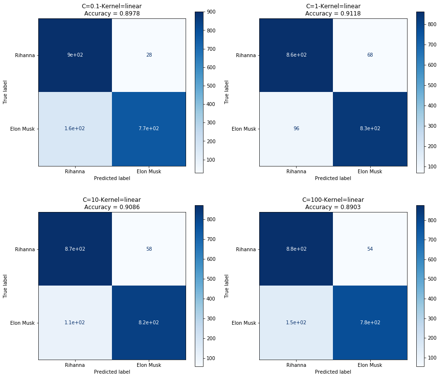

```python
predsLinear1 = { x: pred_G1[x] for x in pred_G1 if "linear" in x}
fig, axs = plt.subplots(nrows=2, ncols=2, figsize=(15, 13.5))
for idx, key in enumerate(predsLinear1):
    plot_cm(key, y1_test, predsLinear1, ['Rihanna', 'Elon Musk'], ax=axs[idx//2][idx%2])
```

Las siguientes matrices de confusión se corresponden con el caso del kernel RBF. Las conclusiones que extraemos de la predicción de estos modelos son las siguientes:

- Los modelos son muy sensibles al valor de $\gamma$. Cuando $\gamma$ es muy pequeño ('auto'), el modelo se restringe demasiado y no puede capturar la complejidad de los datos, clasificando a la gran mayoría de tweets de Elon Musk como si fueran de Rihanna. Cuando el valor del parámetro es más alto ($\gamma = 10$), el modelo se ajusta demasiado a los datos de entrenamiento y pierde capacidad de generalización, dando lugar a overfitting y resultados muy malos (no pasan de 0.56).
- Cuando el valor de $\gamma$ es alto, da igual cual sea el parámetro de regularización que usamos, ya que nunca es suficiente para contrarrestar el overfitting. Sin embargo, para un valor bajo de $\gamma$ como 0.1, si añadimos un parámetro C de regularización alto, sí que conseguimos un buen *tradeoff* entre complejidad y ajuste en el entrenamiento, lo que nos da modelos con una precisión de hasta 0.9145.
- Los mejores modelos se obtienen de aplicar valores medios de $\gamma$ o de contrarrestar valores bajos de $\gamma$ con valores medios/altos de C. En particular, llama la atención lo mucho que influye añadir la varianza para obtener el valor de $\gamma$ = 'scale', que obtiene modelos muy buenos en comparación con los modelos obtenidos de aplicar $\gamma$ = 'auto'.

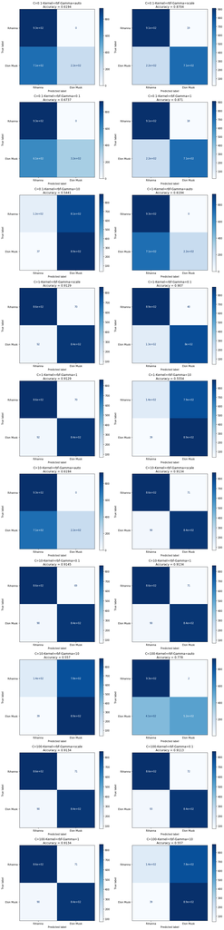

```python
fig, axs = plt.subplots(nrows=10, ncols=2, figsize=(15, 68))
predsRBF1 = { x: pred_G1[x] for x in pred_G1 if "rbf" in x}
for idx, key in enumerate(predsRBF1):
    plot_cm(key, y1_test, predsRBF1, ['Rihanna', 'Elon Musk'], ax=axs[idx//2][idx%2])
```

Como últimos modelos del caso Rihanna - Elon Musk, mostramos los que resultan de aplicar un kernel polinomial. En general, los resultados son peores. Por un lado, cuando el parámetro C es bajo, el modelo construido es demasiado simple y las predicciones que se obtienen son aproximadamente del 50%, ya que se clasifican casi todos los tweets como de Elon Musk. Por otro lado, la influencia del parámetro $\gamma$ es similar al caso anterior: cuando es muy alta o muy baja, los resultados son muy pobres ya que no se consigue generalizar correctamente. En particular, cuando $\gamma$ es alto, el valor que se obtiene de la función polinómica es el mismo que el de la función lineal pero multiplicado por $\gamma$ y elevado a 3, lo que hace que esos modelos se ajusten muchísimo más a los datos de entrenamiento y haya un gran *overfitting*.

Además, comparándolo con el caso de `rbf`, cuando el valor de $\gamma$ es bajo, la influencia que tiene sobre el modelo es mucho mayor, ya que por muy alto que sea el valor de C, no se consigue que haya un balance como en el caso de `rbf`, al estar elevando ese valor de $\gamma$ al cubo.

En resumen, los únicos resultados positivos se obtienen cuando los valores $\gamma$ y C son intermedios, aunque no llegan a ser mejores que los del caso de `rbf`, siendo el *accuracy* máximo obtenido de 0.8925.

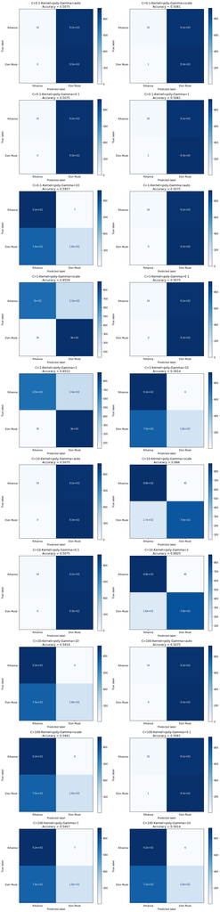

```python
fig, axs = plt.subplots(nrows=10, ncols=2, figsize=(15, 68))
predsPoly1 = { x: pred_G1[x] for x in pred_G1 if "poly" in x}
for idx, key in enumerate(predsPoly1):
    plot_cm(key, y1_test, predsPoly1, ['Rihanna', 'Elon Musk'], ax=axs[idx//2][idx%2])
```

A continuación mostramos el mejor modelo obtenido de la comparación entre Rihanna y Elon Musk, creando una lista de tuplas que contiene cada uno de los nombres de los modelos y el *accuracy* en ese caso. Para obtener el mejor modelo, calculamos el de mayor accuracy de la lista de tuplas, usando la función `itemgetter`.

El modelo obtenido tiene como parámetros C=10, $\gamma$ = 0.1 y kernel='rbf'. El hecho de que el *accuracy* sea de 0.9145 nos indica que el modelo ha sabido capturar muy bien las diferencias entre ambas personalidades.

```python
acc_G1 = [(key, accuracy_score(y1_test, pred_G1[key])) for key in pred_G1]
max(acc_G1,key=itemgetter(1))
```

```
('C=10-Kernel=rbf-Gamma=0.1', 0.9145161290322581)
```

### Chris Haynes vs Adrian Wojnarowski

Pasamos a mostrar ahora los resultados de los modelos que comparan a Chris Haynes con Adrian Wojnarowski. Como en el caso anterior, las primeras matrices que mostramos son las que tienen el kernel tipo `linear`.

En este caso, se nota más la penalización ocasionada por tener un parámetro de regularización alto, ya que se está aplicando un modelo que se ajusta más a los datos de entrenamiento, y al tratarse de dos personalidades cuyos tweets son muy parecidos, le cuesta generalizar más y el error de test es mayor.

En general, los resultados son peores que en el caso anterior con kernel `linear`, lo que concuerda con nuestra hipótesis inicial, debido a la similitud entre ambos periodistas. Por otro lado, de igual manera que en el caso anterior, las mejores predicciones se obtienen con valores de C intermedios.

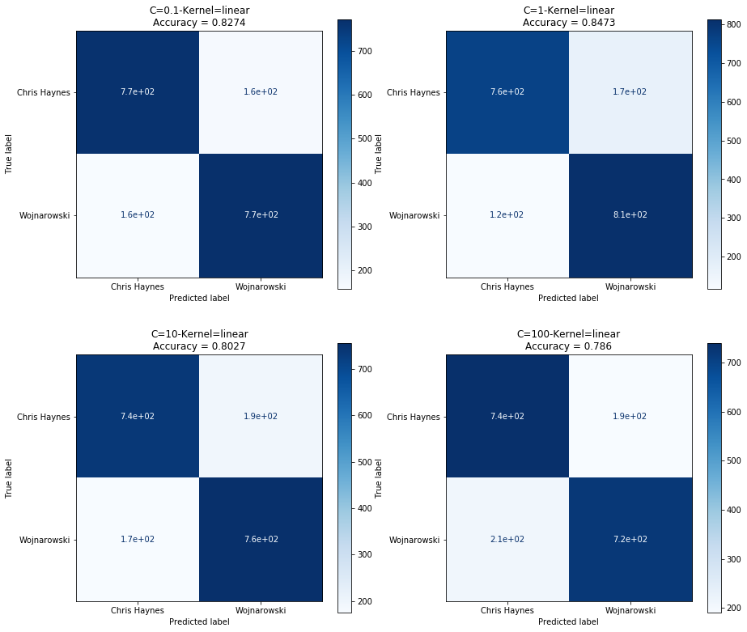

```python
predsLinear2 = { x: pred_G2[x] for x in pred_G2 if "linear" in x}
fig, axs = plt.subplots(nrows=2, ncols=2, figsize=(15, 13.5))
for idx, key in enumerate(predsLinear2):
    plot_cm(key, y2_test, predsLinear2, ['Chris Haynes', 'Wojnarowski'], ax=axs[idx//2][idx%2])
```

Mostramos a continuación los resultados correspondientes al kernel `rbf`. Sobre ellos observamos lo siguiente:

- De igual manera que para el grupo 1, cuando el valor de $\gamma$ es alto, no hay nada que se pueda hacer para compensarlo, obteniéndose valores de *accuracy* extremadamente malos (menores de 0.50, peor que lanzar una moneda al aire). Además, en esos casos se observa que la gran mayoría de tweets se predicen como de Wojnarowski.
- Los tweets de Wojnarowski se predicen casi de manera perfecta en la mayoría los casos, mientras que para predecir los de Chris Haynes el algoritmo tiene más problemas. Esto puede deberse a que el mismo sabe identificar las diferencias entre los tweets que hablan de Yahoo y los que hablan de ESPN, pero los que no mencionan la cadena del periodista se clasifican como de Wojnarowski al tener los tweets de ambos la misma estructura.
- Cuando se obtienen modelos simples (con valores de C y $\gamma$ bajos), los resultados no son tan malos como en el caso de Rihanna y Elon Musk. Esto puede deberse a lo que hemos mencionado anteriormente: pese a que el modelo es simple, sabe diferenciar bien los tweets de Wojnarowski del resto, errando únicamente en los tweets de Chris Haynes que son muy similares a los de Wojnarowski.
- Como en el caso anterior, los mejores modelos se obtienen cuando $\gamma = 1$ y $\gamma$ = 'scale', variando el *accuracy* en función del parámetro de regularización C, que tiene menos influencia que $\gamma$ y que da mejores resultados cuando toma valores intermedios. El mejor modelo se corresponde con los casos de C=1 y $\gamma$ = 'scale', y de C=1 y $\gamma$=1, con un *accuracy* de 0.8462. También se obtienen buenos resultados cuando el valor de $\gamma$ es bajo y se compensa con un valor alto del parámetro C.

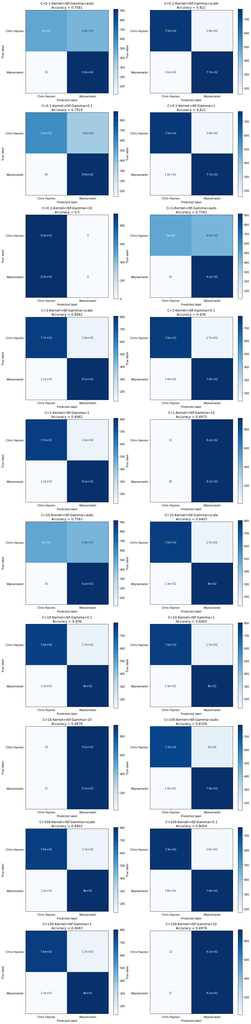

```python
predsRBF2 = { x: pred_G2[x] for x in pred_G2 if "rbf" in x}
fig, axs = plt.subplots(nrows=10, ncols=2, figsize=(15, 68))
for idx, key in enumerate(predsRBF2):
    plot_cm(key, y2_test, predsRBF2, ['Chris Haynes', 'Wojnarowski'], ax=axs[idx//2][idx%2])
```

Por último, mostramos las matrices de confusión y los valores de *accuracy* para el caso del kernel polinomial.

- Como en el caso de Rihanna y Elon Musk, el tener un valor de $\gamma$ alto hace que el sobreentrenamiento sea muy grande, y se obtengan resultados de tests pobres. Además, cuando $\gamma$ es bajo, el valor de C no tiene influencia sobre el modelo ya que no se consigue compensar el modelo tan simple que proporciona ese valor de $\gamma$. Ambas circunstancias se ven acentuadas por el hecho de que $\gamma$ se eleva al cubo, lo que hace que su influencia sea mucho mayor.
- Como en el caso de Rihanna y Elon Musk, los mejores resultados se corresponden con valores de C y $\gamma$ intermedios, y son en general peores que en el resto de kernels.

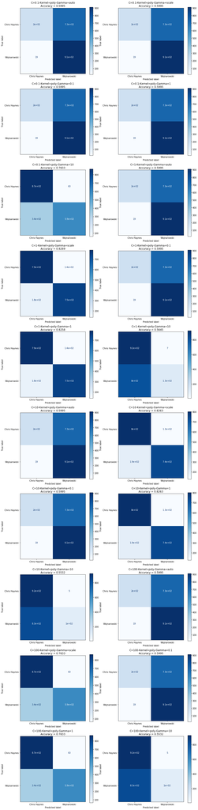

```python
predsPoly2 = { x: pred_G2[x] for x in pred_G2 if "poly" in x}
fig, axs = plt.subplots(nrows=10, ncols=2, figsize=(15, 68))
for idx, key in enumerate(predsPoly2):
    plot_cm(key, y2_test, predsPoly2, ['Chris Haynes', 'Wojnarowski'], ax=axs[idx//2][idx%2])
```

A continuación mostramos el *accuracy* máximo y el caso con el que se corresponde, haciendo uso de nuevo de la función `itemgetter`.

El máximo *accuracy* que se obtiene es de 0.8473, y se corresponde con un modelo de kernel lineal y con un parámetro de regularización de 1.

```python
acc_G2 = [(key, accuracy_score(y2_test, pred_G2[key])) for key in pred_G2]
max(acc_G2,key=itemgetter(1))
```

```
('C=1-Kernel=linear', 0.8473118279569892)
```

Como curiosidad, vamos a comprobar la teoría de que las palabras 'ESPN' y 'Yahoo' son importantes a la hora de realizar la predicción. Para ello, usando el mejor modelo obtenido en este caso, vamos a obtener el vector `coef_` que devuelve el modelo. Este vector contiene unos pesos que representan las coordenadas del vector que son ortogonales al hiperplano, y su dirección indica la clase de la predicción: dirección negativa para la clase con valor de salida 0 (Chris Haynes) y dirección positiva para la clase de salida 1 (Wojnarowski). Por tanto, las palabras que tengan coeficiente muy positivo sirven para decidir que el tweet es de Wojnarowski, y las que tienen signo negativo sirven para decidir que el tweet es de Chris Haynes.

```python
best_model = svm.SVC(C=1, kernel='linear')
best_model.fit(train_vect_G2, y2_train)
```

```
SVC(C=1, break_ties=False, cache_size=200, class_weight=None, coef0=0.0,
    decision_function_shape='ovr', degree=3, gamma='scale', kernel='linear',
    max_iter=-1, probability=False, random_state=None, shrinking=True,
    tol=0.001, verbose=False)
```

A continuación mostramos las palabras de los tweets con los coeficientes más altos (importantes para decidir que el tweet es de Wojnarowski), y con los coeficientes más bajos (usadas para decidir que el tweet es de Chris Haynes). Para ello hemos usado el nombre de las *features* que nos devuelve el vectorizer y el vector `coef_`.

```python
imp_Woj = [(x,y) for x,y in sorted(zip(best_model.coef_[0],vectorizer_G2.get_feature_names()), reverse = True)][:5]
imp_Woj
```

```
[(3.1598268735980906, 'woj'),
 (2.4087119070293435, 'espn'),
 (2.231849432271638, 'story'),
 (2.1999152936505726, 'kirkgoldsberry'),
 (2.147982847234766, 'wojespn')]
```

```python
imp_CH = [(x,y) for x,y in sorted(zip(best_model.coef_[0],vectorizer_G2.get_feature_names()))][:5]
imp_CH
```

```
[(-5.54867580929921, 'yahoo'),
 (-3.4021910544835636, 'thesteinline'),
 (-3.211641074276296, 'chrisbhaynes'),
 (-3.008217782506672, 'marcjspearsespn'),
 (-2.7960394269904136, 'posted')]
```

Se puede observar que para Wojnarowski la segunda palabra más importante es espn, mientras que para Haynes la más importante es yahoo, lo que quiere decir que el algoritmo es bueno distinguiendo ambos tipos de tweets. A continuación vemos un gráfico con las palabras más importantes para el algoritmo en función de la clase.

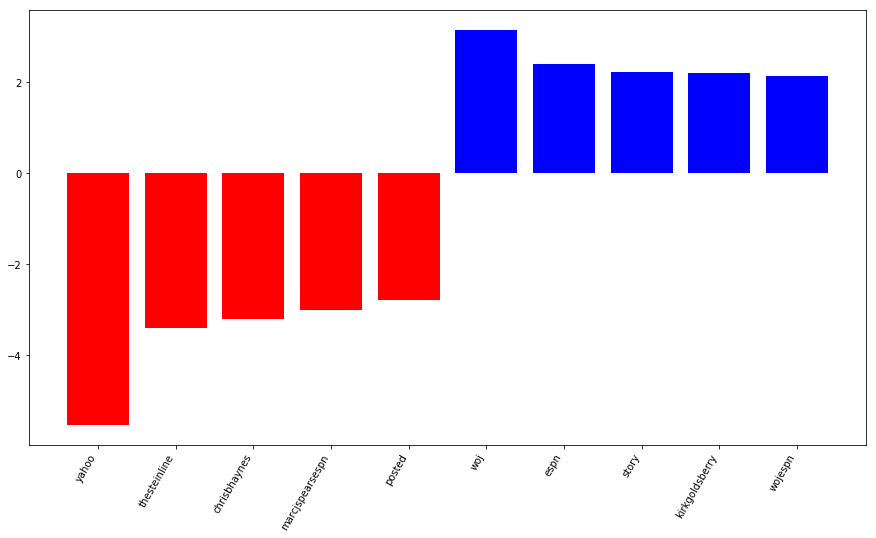

```python
plt.figure(figsize=(15, 8))
coefs = np.hstack([[x for x,_ in imp_CH], [x for x,_ in imp_Woj]])
words = np.hstack([[y for _,y in imp_CH], [y for _,y in imp_Woj]])
colors = ['red' if c < 0 else 'blue' for c in coefs]
plt.bar(np.arange(10), coefs, color=colors)
plt.xticks(np.arange(0, 10), words, rotation=60, ha='right')
plt.show()
```

### Conclusiones extraídas de ambos clasificadores

Como era lógico, hemos obtenido que los tweets de la pareja de celebridades distintas se predicen con una mayor precisión que los tweets de la pareja de personalidades parecidas. El hecho de que Rihanna y Elon Musk sean tan distintos ha hecho que el valor de *accuracy* sea superior a 0.9. Por otro lado, el mejor modelo correspondiente al grupo 2, no tiene un *accuracy* excesivamente bajo, lo que indica que el modelo ha sido capaz de capturar en su mayoría los estilos de escritura de ambos periodistas, y ha sabido ver que una parte de los tweets de Wojnarowski mencionaban a ESPN y una parte de los tweets de Chris Haynes mencionaban a Yahoo. Llama la atención, como hemos indicado antes, que los tweets de Wojnarowski se predicen mucho mejor que los de Chris Haynes, lo que se puede deber a que son más parecidos entre sí y a que la mayoría de los tweets de Chris Haynes están escritos en el mismo estilo formal que utiliza Wojnarowski.

# Análisis de sentimientos

Pasamos a explicar el ejercicio opcional sobre análisis de sentimientos de los tweets de cada uno de los personajes usando VADER, y en particular, la librería `vaderSentiment`. Esta librería está construida basada en un léxico de 7500 palabras (tal y como se indica en la [documentación](https://github.com/cjhutto/vaderSentiment)), cada una de ellas con una puntuación o valencia asignada, que varía entre -4 y 4. Por ejemplo, la palabra "great" tiene una valencia de 3.1. Usando esas valencias, y creado un analizador usando la función `SentimentIntensityAnalyzer`, podemos obtener cuánta parte positiva, negativa y neutral tiene una determinada frase.

A continuación importamos esta función y construimos el analizador. Además, definimos una función denominada `get_sentiments_scores` que, dada una frase (en nuestro caso un tweet), obtiene las diferentes puntuaciones extraídas de ese tweet usando el método `polarity_scores`. Los valores que devuelve esta función los explicamos con un ejemplo a continuación.

```python
from vaderSentiment.vaderSentiment import SentimentIntensityAnalyzer
analyser = SentimentIntensityAnalyzer()

def get_sentiments_scores(tweet):
    score = analyser.polarity_scores(tweet)
    return score
```

En el siguiente ejemplo vemos las puntuaciones que devuelve el método usando uno de los tweets de Rihanna. Como se puede observar, es un tweet muy positivo, en el que está animando a un amigo suyo y le está dando las gracias. Los valores que devuelve la función son los siguientes:

```python
print(dict_celebs[0]['tweets'][3])
print(get_sentiments_scores(dict_celebs[0]['tweets'][3]))
```

```
Big ups to my gusband Jahleel. Thank you for being a true rider! Look at us bro!!! And thank you @asvpxrocky for representing us on the carpet and always being so supportive of @FentyOfficial !! And to the epic duo that presented, thank you! @tylerthecreator and @janetjackson !
{'neg': 0.0, 'neu': 0.741, 'pos': 0.259, 'compound': 0.9236}
```

En el siguiente trozo de código vamos a crear dos diccionarios: el primero de ellos (`sentiments`) tiene el cometido de guardar la media de cada uno de los valores devueltos por `polarity_scores` para cada uno de los personajes elegidos, y el segundo (`types`) guarda el número de tweets positivos, negativos y neutrales de los mismos.

Para rellenar ambos diccionarios, recorremos el diccionario creado al comienzo de la práctica con todos los tweets de cada usuario, y aplicamos a cada tweet la función `get_sentiments_scores` para obtener los *scores*, y rellenamos ambos diccionarios siguiendo el siguiente proceso:

- Para el diccionario que contiene la media de los valores `compound`, `pos`, `neg` y `neu`, lo que hacemos es sumar todos los *scores* para el usuario y finalmente dividirlo por el número de tweets cuando ya se han procesado todos.
- Para obtener el número de tweets que se corresponden con cada tipo de sentimiento, simplemente aplicamos la distinción explicada antes, es decir, distinguimos en función del valor de `compound`, y sumamos uno al valor del diccionario que se corresponda con el sentimiento del tweet.

El motivo de realizar dos diccionarios de diccionarios de esta forma es que podemos transformarlos de manera sencilla a un *dataframe* usando Pandas, como veremos a continuación.

```python
sentiments = { celeb : {'pos': 0, 'neg': 0, 'neu': 0, 'compound': 0} for celeb in celebs}
types = { celeb: {'negative':0, 'positive':0, 'neutral': 0} for celeb in celebs}
for celeb in dict_celebs:
    name = celeb['name']
    for tweet in celeb['tweets']:
        score = get_sentiments_scores(tweet)
        sentiments[name]['pos'] += score['pos']
        sentiments[name]['neg'] += score['neg']
        sentiments[name]['neu'] += score['neu']
        sentiments[name]['compound'] += score['compound']

        if score['compound'] >= 0.05:
            types[celeb['name']]['positive'] += 1
        elif score['compound'] <= -0.05:
            types[celeb['name']]['negative'] += 1
        else:
            types[celeb['name']]['neutral'] += 1
    # dividimos entre el número total de tweets para obtener la media, y lo guardamos en el diccionario
    sentiments[name] = { x: round(sentiments[name][x]/len(celeb['tweets']),5) for x in sentiments[name]}
```

A continuación se muestra el dataframe correspondiente a los valores medios obtenidos en el diccionario `sentiments`. En él podemos observar como todos las celebridades, en media, han publicado tweets que son positivos, siendo el menos positivo de ellos Chris Haynes. Además, es también el periodista de Yahoo el que tiene mayor ratio negativo medio a lo largo de todos sus tweets, lo cual puede deberse a tweets que informan de noticias negativas y de lesiones de jugadores. Sin embargo, su compañero de profesión, Wojnarowski, tiene un `compound` mucho mayor y un menor ratio negativo medio en sus tweets. Por otro lado, Rihanna y Elon Musk tienen tweets con sentimientos parecidos, siendo más positivos los tweets de Elon Musk, el cual habla con frecuencia de los éxitos de su empresa.

```python
sentiments_df = pd.DataFrame(sentiments)
sentiments_df
```

|  | rihanna | elonmusk | ChrisBHaynes | wojespn |
| --- | --- | --- | --- | --- |
| pos | 0.11599 | 0.15635 | 0.07634 | 0.08086 |
| neg | 0.04321 | 0.03805 | 0.04576 | 0.03008 |
| neu | 0.83888 | 0.80530 | 0.87789 | 0.88906 |
| compound | 0.14863 | 0.17289 | 0.09256 | 0.16507 |

```python
types_df = pd.DataFrame(types)
types_df
```

|  | rihanna | elonmusk | ChrisBHaynes | wojespn |
| --- | --- | --- | --- | --- |
| negative | 353 | 393 | 722 | 487 |
| positive | 1051 | 1429 | 1241 | 1509 |
| neutral | 1727 | 1360 | 1234 | 1198 |

Para observar el número de tweets de cada tipo de forma gráfica, hemos usado dos gráficos de tipo *stacked*, en los que mostramos los valores de la tabla anterior.

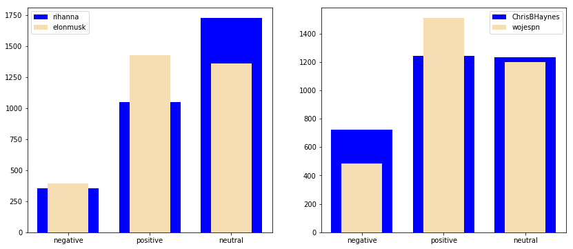

```python
fig, axs = plt.subplots(nrows=1, ncols=2, figsize=(14, 6))

types_df['rihanna'].plot(kind='bar', color='blue', width=.75, legend=True, ax = axs[0], rot=0)
types_df['elonmusk'].plot(kind='bar', color='wheat', width=.5, legend=True, ax = axs[0], rot=0)

types_df['ChrisBHaynes'].plot(kind='bar', color='blue', width=.75, legend=True, ax = axs[1], rot=0)
types_df['wojespn'].plot(kind='bar', color='wheat', width=.5, legend=True, ax = axs[1], rot=0)
```

Una vez estudiado el sentimiento de los tweets de las celebridades, se siguió leyendo la documentación en busca de extaer algún contenido interesante más. Un aspecto importante que me llamó la atención fue que permite el procesamiento de emojis, y es capaz de asignar una valencia a los mismos. Observando los tweets de nuestras celebridades, se ha comprobado que Rihanna es la que más emojis pone en sus tweets.

Realizando pruebas, nos hemos dado cuenta de una peculiaridad en el procesamiento del sentimiento de frases con emojis. Si tomamos la siguiente frase: "Catch utf-8 emoji such as such as 💘 and 💋 and 😁", extraída del [github](https://github.com/cjhutto/vaderSentiment) de VADER, se cataloga el tweet como muy positivo debido a los 3 emojis que tiene. Sin embargo, si los juntamos (eliminando las palabras *and*), el algoritmo no es capaz de procesarlos y devuelve un valor neutral de 1.

A continuación se muestran las puntuaciones de ambas frases:

```python
print(get_sentiments_scores("Catch utf-8 emoji such as such as 💘 and 💋 and 😁"))
print(get_sentiments_scores("Catch utf-8 emoji such as such as 💘💋😁"))
```

```
{'neg': 0.0, 'neu': 0.746, 'pos': 0.254, 'compound': 0.7003}
{'neg': 0.0, 'neu': 1.0, 'pos': 0.0, 'compound': 0.0}
```

Probando con uno de los tweets de Rihanna, se observa el mismo patrón, si eliminamos uno de los emojis, se obtiene un sentimiento negativo, pero si dejamos ambos juntos, se obtiene un sentimiento totalmente neutral.

```python
print('Tweet de Rihanna', dict_celebs[0]['tweets'][180])
print(get_sentiments_scores(dict_celebs[0]['tweets'][180]))

print('\nTweet de Rihanna sin emoji: #repost 😢')
print(get_sentiments_scores('#repost 😢'))
```

```
Tweet de Rihanna #repost 😢💔
{'neg': 0.0, 'neu': 1.0, 'pos': 0.0, 'compound': 0.0}

Tweet de Rihanna sin emoji: #repost 😢
{'neg': 0.608, 'neu': 0.392, 'pos': 0.0, 'compound': -0.4767}
```

Debido a este motivo, se ha decidido realizar un procesamiento de los tweets que tienen emojis, y añadir la palabra *and* entre todos los emojis consecutivos, y así poder observar los resultados del análisis del sentimiento con este problema corregido.

Para poder identificar los emojis, hacemos uso de la librería [emoji](https://pypi.org/project/emoji/). Esta librería incluye una función denominada `get_emoji_regexp()` que devuelve un patrón con una expresión regular que nos permite reconocerlos.

De esta manera, usando la librería `re` y su función `search`, podemos saber si un tweet contiene al menos un emoji.

La siguiente función se encarga de separar los emojis y añadir los tweets resultantes a un nuevo diccionario llamado `new_tweets` usando la librería `emoji` para identificarlos. Por cada tweet, si contiene un emoji, se procesan sus caracteres para que cuando encuentre el primero, se compruebe si el siguiente carácter es también un emoji, y en cuyo caso se añada la palabra *and* en medio.

```python
def separate_emojis(dict_celebs):
    new_tweets = { celeb: [] for celeb in celebs }
    for dict in dict_celebs:
        for tweet in dict['tweets']:
            # creamos un string auxiliar que se irá modificando conforme se separen los tweets
            aux = tweet
            # si contiene un emoji, se procesa el tweet
            if re.search(emoji.get_emoji_regexp(), tweet):
                add = 0
                for idx,c in enumerate(tweet):
                    # si el carácter es exactamente un emoji y no estamos en la última posición del tweet
                    if re.search(emoji.get_emoji_regexp(),c) and idx != len(tweet)-1:
                        # si el siguiente es también un emoji, se añade la palabra and en medio
                        if re.search(emoji.get_emoji_regexp(),tweet[idx+1]):
                            aux = aux[:idx+1+add] + ' and ' + aux[idx+1+add:]
                            # se actualiza la nueva posición de inserción sumando el nº de caracteres de ' and '
                            add += 5
            new_tweets[dict['name']].append(aux)
    return new_tweets
```

```python
new_tweets = separate_emojis(dict_celebs)
```

Si observamos ahora el mismo tweet de Rihanna mostrado arriba, se observa como los emojis sí están separados y el `compound` es muy bajo, ya que se han tenido en cuenta ambos emojis.

```python
print(new_tweets['rihanna'][180])
print(get_sentiments_scores(new_tweets['rihanna'][180]))
```

```
#repost 😢 and 💔
{'neg': 0.608, 'neu': 0.392, 'pos': 0.0, 'compound': -0.7351}
```

A continuación realizamos el mismo proceso de extracción de sentimientos realizado al comienzo del apartado, pero usando los nuevos tweets recientemente procesados.

```python
sentiments_corrected = { celeb : {'pos': 0, 'neg': 0, 'neu': 0, 'compound': 0} for celeb in celebs}
types_corrected = { celeb: {'negative':0, 'positive':0, 'neutral': 0} for celeb in celebs}
for celeb in celebs:
    for tweet in new_tweets[celeb]:
        score = get_sentiments_scores(tweet)
        sentiments_corrected[celeb]['pos'] += score['pos']
        sentiments_corrected[celeb]['neg'] += score['neg']
        sentiments_corrected[celeb]['neu'] += score['neu']
        sentiments_corrected[celeb]['compound'] += score['compound']

        if score['compound'] >= 0.05:
            types_corrected[celeb]['positive'] += 1
        elif score['compound'] <= -0.05:
            types_corrected[celeb]['negative'] += 1
        else:
            types_corrected[celeb]['neutral'] += 1
    sentiments_corrected[celeb] = { x: round(sentiments_corrected[celeb][x]/len(new_tweets[celeb]),5) for x in sentiments_corrected[name]}
```

Convertimos los dos diccionarios obtenidos a *dataframe* y los mostramos. Se puede observar que para los valores medios de los ratios y el `compound`, el resultado no cambia prácticamente. Esto se debe a que el número de tweets con emojis no es lo suficientemente grande y los emojis pueden ser tanto positivos como negativos. Lo máximo que cambia el `compound` es en el caso de Elon Musk, en el que sube algo más de 0.005.

```python
sentiments_corrected_df = pd.DataFrame(sentiments_corrected)
sentiments_corrected_df
```

|  | rihanna | elonmusk | ChrisBHaynes | wojespn |
| --- | --- | --- | --- | --- |
| pos | 0.11600 | 0.15868 | 0.07713 | 0.08093 |
| neg | 0.04369 | 0.03874 | 0.04622 | 0.03009 |
| neu | 0.83840 | 0.80227 | 0.87664 | 0.88898 |
| compound | 0.15003 | 0.17868 | 0.09480 | 0.16544 |

Con respecto a los tipos, sí se nota una mayor diferencia con respecto a los anteriores. En el siguiente *dataframe* mostramos los tipos extraídos antes (acabados en _b de before) con los nuevos. Se puede observar que el número de tweets neutrales disminuye para todos los usuarios menos para Wojnarowski (el cual no usa prácticamente emojis), lo que quiere decir que el procesamiento realizado ha servido para etiquetar algunos de los tweets neutrales como positivos o negativos.

```python
types_corrected_df = pd.DataFrame(types_corrected)
types_df.columns = ['rihanna_b','elonmusk_b','ChrisBHaynes_b','wojespn_b']
pd.concat([types_df, types_corrected_df], axis = 1)
```

|  | rihanna_b | elonmusk_b | ChrisBHaynes_b | wojespn_b | rihanna | elonmusk | ChrisBHaynes | wojespn |
| --- | --- | --- | --- | --- | --- | --- | --- | --- |
| negative | 353 | 393 | 722 | 487 | 357 | 397 | 724 | 486 |
| positive | 1051 | 1429 | 1241 | 1509 | 1062 | 1452 | 1249 | 1510 |
| neutral | 1727 | 1360 | 1234 | 1198 | 1712 | 1333 | 1224 | 1198 |